# Long_Text_Similarity_Analysis

Anonymous

2023-05-02

```r
library(tidyverse)
library(reticulate)
```

Import the python packages, to calculate the similarity

```python
import pandas as pd
import statistics
from sentence_transformers import SentenceTransformer, util
```

Data description:

I set 192 (128*1.5) as the threshold for super long text, texts between 128 and 192 tokens are not considered.

Here our sample data are 100 videos from 5 countries: de, uk, es, it, us. 20 random videos for each country.

sv and nl texts are not sampled, because only a few of the texts are considered as super long text, (1/704 for nl, 7/537 for sv).

Language of the text: only official languages of the countries, YouTube data language detection was done by `fasttext`.

```python
data = pd.read_csv("long_text_similarity.csv")
```

Import BERT multilingual base model.

```python
# import model
model = SentenceTransformer('bert-base-multilingual-cased')
```

[output not shown]

Extract the texts that we want to embed. Preparation of the text columns are done in the random sampling process (code avaiable upon request).

There are three types of texts we need to embed.

1. `headtoken_nolink`: First 128 tokens with very slight data cleaning – with only weblink removed.
2. `headtoken_cleantext`: Frist 128 tokens with deeper data cleaning – with weblink, punctuations and stopwords removed
3. `rawtext`: raw text, the original text from youtube data.

Two similarity calculations are done:

**Scenario 1**: `headtoken_nolink` vs `rawtext`

**Scenario 2**: `headtoken_cleantext` vs `rawtext`

```python
headtoken_nolink = data['headtoken_nolink'].tolist()
headtoken_cleantext = data['headtoken_cleantext'].tolist()
rawtext = data['fulltext'].tolist()
```

## Embedding and text similarity calculation

### Embedding

```python
nolink_embed = model.encode(headtoken_nolink, convert_to_tensor=True)
cleantext_embed = model.encode(headtoken_cleantext, convert_to_tensor=True)
rawtext_embed = model.encode(rawtext, convert_to_tensor=True)
```

### Scenario 1: `headtoken_nolink` vs `rawtext`

```python
similarity_nolink_rawtext = []

for i in range(len(rawtext)):
    similarity_nolink_rawtext.append(util.cos_sim(nolink_embed[i], rawtext_embed[i]).numpy().item())

similarity_nolink_rawtext
```

```
## [0.8210353255271912, 0.8583601713180542, 0.8816215395927429, 0.8589133620262146, 0.860874354839325, 0.8789250254631042, 0.8539052605628967, 0.8744214177131653, 0.8720240592956543, 0.8531592488288879, 0.8501850366592407, 0.8664414882659912, 0.8317530155181885, 0.8884006142616272, 0.956440985202789…
```

### Scenario 2: `headtoken_cleantext` vs `rawtext`

```python
similarity_cleantext_rawtext = []

for i in range(len(rawtext)):
    similarity_cleantext_rawtext.append(util.cos_sim(cleantext_embed[i], rawtext_embed[i]).numpy().item())

similarity_cleantext_rawtext
```

```
## [0.8098515868186951, 0.7952378988265991, 0.747818112373352, 0.7792314887046814, 0.8105295300483704, 0.8232815861701965, 0.8119724988937378, 0.8316397070884705, 0.8265544176101685, 0.7838039994239807, 0.8326834440231323, 0.7915053367614746, 0.7417224645614624, 0.7824809551239014, 0.893757939338684…
```

Assign them to the dataframe

```python
data['similarity_nolink_rawtext'] = similarity_nolink_rawtext
data['similarity_cleantext_rawtext'] = similarity_cleantext_rawtext
```

### Simple stats

```python
# simple stats

def simple_stats(inputdata):
    print("the average similarity is: ", statistics.mean(inputdata))
    print("the median value is: ", statistics.median(inputdata))
    print("the max value is: ", max(inputdata))
    print("the min value is: ", min(inputdata))
    print("the sd is: ", statistics.stdev(inputdata))
```

#### Simple stats: scenario 1

```python
simple_stats(similarity_nolink_rawtext)
```

```
## the average similarity is:  0.8488470613956451
## the median value is:  0.8535322546958923
## the max value is:  0.9564409852027893
## the min value is:  0.6511541604995728
## the sd is:  0.034249576442867885
```

#### Simple stats: scenario 2

```python
simple_stats(similarity_cleantext_rawtext)
```

```
## the average similarity is:  0.7745225477218628
## the median value is:  0.7794573903083801
## the max value is:  0.8937579393386841
## the min value is:  0.6343267560005188
## the sd is:  0.03869015736705407
```

### Extract and reshape data for a deeper investigation

```python
plotdf = data[['country', 'fulltext_length', 'similarity_nolink_rawtext', 'similarity_cleantext_rawtext']]
plotdf
```

```
##    country  ...  similarity_cleantext_rawtext
## 0       de  ...                      0.809852
## 1       de  ...                      0.795238
## 2       de  ...                      0.747818
## 3       de  ...                      0.779231
## 4       de  ...                      0.810530
## ..     ...  ...                           ...
## 95      us  ...                      0.701098
## 96      us  ...                      0.707312
## 97      us  ...                      0.777585
## 98      us  ...                      0.800647
## 99      us  ...                      0.761973
##
## [100 rows x 4 columns]
```

```python
plotdf = plotdf.melt(id_vars=['country', 'fulltext_length'],
                     value_vars=['similarity_nolink_rawtext', 'similarity_cleantext_rawtext'],
                     var_name='class', value_name='value')
plotdf
```

```
##     country  fulltext_length                         class     value
## 0        de              550     similarity_nolink_rawtext  0.821035
## 1        de              468     similarity_nolink_rawtext  0.858360
## 2        de              511     similarity_nolink_rawtext  0.881622
## 3        de              510     similarity_nolink_rawtext  0.858913
## 4        de              506     similarity_nolink_rawtext  0.860874
## ..      ...              ...                           ...       ...
## 195      us              592  similarity_cleantext_rawtext  0.701098
## 196      us              954  similarity_cleantext_rawtext  0.707312
## 197      us              349  similarity_cleantext_rawtext  0.777585
## 198      us              815  similarity_cleantext_rawtext  0.800647
## 199      us             1045  similarity_cleantext_rawtext  0.761973
##
## [200 rows x 4 columns]
```

## Analysis

```r
# convert the pandas df object to R DF
plotdf <- py$plotdf
```

### Simple plot

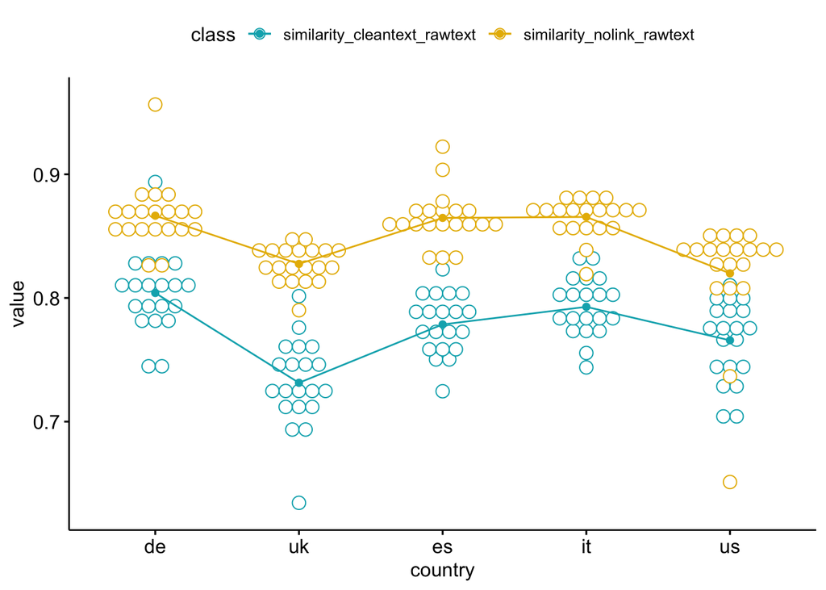

```r
ggpubr::ggline(plotdf, x = "country", y = "value", color = "class",
       add = c("mean_se", "dotplot"),
       palette = c("#00AFBB", "#E7B800"))
```

### Two way anova

```r
# anova
mod <- lm(value ~ country + class, data = plotdf)
car::Anova(mod) %>% report::report()
```

```
## The ANOVA suggests that:
##
##   - The main effect of country is statistically significant and large (F(4, 194)
## = 26.88, p < .001; Eta2 (partial) = 0.36, 95% CI [0.26, 1.00])
##   - The main effect of class is statistically significant and large (F(1, 194) =
## 315.08, p < .001; Eta2 (partial) = 0.62, 95% CI [0.55, 1.00])
##
## Effect sizes were labelled following Field's (2013) recommendations.
```

```r
rstatix::tukey_hsd(mod) %>% select(-null.value) %>% print(n = 20)
```

```
## # A tibble: 11 × 8
##    term    group1       group2 estimate conf.low conf.high    p.adj p.adj.signif
##    <chr>   <chr>        <chr>     <dbl>    <dbl>     <dbl>    <dbl> <chr>
##  1 country de           es     -0.0136  -0.0318    0.00463 2.44e- 1 ns
##  2 country de           it     -0.00610 -0.0243    0.0121  8.88e- 1 ns
##  3 country de           uk     -0.0558  -0.0740   -0.0376  1.45e-13 ****
##  4 country de           us     -0.0425  -0.0607   -0.0242  1.05e- 8 ****
##  5 country es           it      0.00750 -0.0107    0.0257  7.89e- 1 ns
##  6 country es           uk     -0.0422  -0.0604   -0.0240  1.3 e- 8 ****
##  7 country es           us     -0.0289  -0.0471   -0.0106  2.03e- 4 ***
##  8 country it           uk     -0.0497  -0.0679   -0.0315  2.14e-11 ****
##  9 country it           us     -0.0364  -0.0546   -0.0181  1.22e- 6 ****
## 10 country uk           us      0.0133  -0.00489   0.0316  2.63e- 1 ns
## 11 class   similarity_… simil…  0.0743   0.0661    0.0826  1.61e-14 ****
```

Group differences were actually expected.

### Multiple regression

But does the text length matter?

Does the similarity decrease while the text becomes longer?

We answer this question by fitting the similarity data into a linear model.

The simple answer is no, at least not that much. But below are the analysis..

```r
# linear regression
# variable class: two similarity scenarios.
# class 0 = scenario 1 = similarity_nolink_rawtext
# class 1 = scenario 2 = similarity_clantext_rawtext

plotdf$class <- as.factor(plotdf$class)
plotdf$class_binary <- ifelse(plotdf$class=="similarity_nolink_rawtext", 0, 1)

# fit the model, show summary and plot the model
fit <- plotdf %>% lm(value ~ fulltext_length*class_binary,.)
ggiraphExtra::ggPredict(fit, colorAsFactor = TRUE, interactive=TRUE,
                        show.summary = T, jitter = T, se = T)
```

```
##
## Call:
## lm(formula = value ~ fulltext_length * class_binary, data = .)
##
## Residuals:
##       Min        1Q    Median        3Q       Max
## -0.193466 -0.019212  0.004425  0.023519  0.115001
##
## Coefficients:
##                                Estimate Std. Error t value Pr(>|t|)
## (Intercept)                   8.380e-01  1.304e-02  64.248   <2e-16 ***
## fulltext_length               1.908e-05  2.196e-05   0.869   0.3859
## class_binary                 -3.940e-02  1.845e-02  -2.136   0.0339 *
## fulltext_length:class_binary -6.122e-05  3.105e-05  -1.972   0.0501 .
## ---
## Signif. codes:  0 '***' 0.001 '**' 0.01 '*' 0.05 '.' 0.1 ' ' 1
##
## Residual standard error: 0.03631 on 196 degrees of freedom
## Multiple R-squared:  0.5218, Adjusted R-squared:  0.5145
## F-statistic:  71.3 on 3 and 196 DF,  p-value: < 2.2e-16
```

[interactive chart not shown]

```r
report::report(fit)
```

```
## We fitted a linear model (estimated using OLS) to predict value with
## fulltext_length and class_binary (formula: value ~ fulltext_length *
## class_binary). The model explains a statistically significant and substantial
## proportion of variance (R2 = 0.52, F(3, 196) = 71.30, p < .001, adj. R2 =
## 0.51). The model's intercept, corresponding to fulltext_length = 0 and
## class_binary = 0, is at 0.84 (95% CI [0.81, 0.86], t(196) = 64.25, p < .001).
## Within this model:
##
##   - The effect of fulltext length is statistically non-significant and positive
## (beta = 1.91e-05, 95% CI [-2.42e-05, 6.24e-05], t(196) = 0.87, p = 0.386; Std.
## beta = -0.04, 95% CI [-0.13, 0.06])
##   - The effect of class binary is statistically significant and negative (beta =
## -0.04, 95% CI [-0.08, -3.02e-03], t(196) = -2.14, p = 0.034; Std. beta = -0.71,
## 95% CI [-0.81, -0.62])
##   - The effect of fulltext length × class binary is statistically non-significant
## and negative (beta = -6.12e-05, 95% CI [-1.22e-04, 1.94e-08], t(196) = -1.97, p
## = 0.050; Std. beta = -0.10, 95% CI [-0.20, 3.09e-05])
##
## Standardized parameters were obtained by fitting the model on a standardized
## version of the dataset. 95% Confidence Intervals (CIs) and p-values were
## computed using a Wald t-distribution approximation.
```

```
## JOHNSON-NEYMAN INTERVAL
##
## When fulltext_length is INSIDE the interval [-25.15, 3837614.68], the slope
## of class_binary is p < .05.
##
## Note: The range of observed values of fulltext_length is [349.00, 1045.00]
```

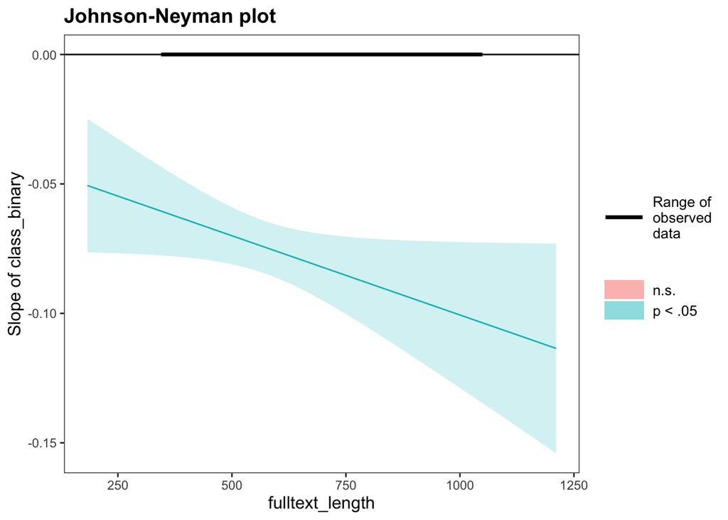

```
## SIMPLE SLOPES ANALYSIS
##
## Slope of class_binary when fulltext_length = 404.6952 (- 1 SD):
##
##    Est.   S.E.   t val.      p
## ------- ------ -------- ------
##   -0.06   0.01    -8.82   0.00
##
## Slope of class_binary when fulltext_length = 570.4900 (Mean):
##
##    Est.   S.E.   t val.      p
## ------- ------ -------- ------
##   -0.07   0.01   -14.47   0.00
##
## Slope of class_binary when fulltext_length = 736.2848 (+ 1 SD):
##
##    Est.   S.E.   t val.      p
## ------- ------ -------- ------
##   -0.08   0.01   -11.62   0.00
```

```r
interactions::sim_slopes(fit, pred = class_binary, modx = fulltext_length, jnplot = T)
```

By using Johnson-Neyman plot we see that when fulltext_length is inside observed interval [349.00, 1045.00], the predicted similarity in scenario 1 is always higher than scenario 2. Which is also what we expected.

In both of the scenarios, given the very little change of regression slope over text length, we consider text length has only a minimum effect on the text similarity, in other words, the representativeness of the first 128 tokens remains relatively stable regardless of the full text length.